# Trips case study document

igor

2025-04-02

# Ask

O projeto está acontecendo porque a companhia está querendo aumentar o número de assinantes anuais.Portanto, sua equipe quer entender como os ciclistas casuais e os membros anuais usam as bicicletas Cyclistic de forma diferente

```r
library(tidyverse)
library(janitor)
library(skimr)
library(leaflet)
```

# Prepare

Os dados são compartilhados pela Lyft Bikes and Scooters, LLC (“Bikeshare”)

A Lyft Bikes and Scooters, LLC (“Bikeshare”) opera o serviço de compartilhamento de bicicletas Divvy da cidade de Chicago (“Cidade”). A Bikeshare e a cidade estão comprometidas em apoiar o ciclismo como uma opção de transporte alternativa. Como parte desse compromisso, a cidade permite que a Bikeshare disponibilize certos dados do sistema Divvy de propriedade da cidade (“Dados”) ao público, sujeitos aos termos e condições deste Contrato de Licença (“Contrato”). Ao acessar ou usar qualquer um dos Dados, você concorda com todos os termos e condições deste Contrato.

Carregando data

```r
trips_2024_01 = read_csv("CSV/202401-divvy-tripdata/202401-divvy-tripdata.csv")
trips_2024_02 = read_csv("CSV/202402-divvy-tripdata/202402-divvy-tripdata.csv")
trips_2024_03 = read_csv("CSV/202403-divvy-tripdata/202403-divvy-tripdata.csv")
trips_2024_04 = read_csv("CSV/202404-divvy-tripdata/202404-divvy-tripdata.csv")
trips_2024_05 = read_csv("CSV/202405-divvy-tripdata/202405-divvy-tripdata.csv")
trips_2024_06 = read_csv("CSV/202406-divvy-tripdata/202406-divvy-tripdata.csv")
trips_2024_07 = read_csv("CSV/202407-divvy-tripdata/202407-divvy-tripdata.csv")
trips_2024_08 = read_csv("CSV/202408-divvy-tripdata/202408-divvy-tripdata.csv")
trips_2024_09 = read_csv("CSV/202409-divvy-tripdata/202409-divvy-tripdata.csv")
trips_2024_10 = read_csv("CSV/202410-divvy-tripdata/202410-divvy-tripdata.csv")
trips_2024_11 = read_csv("CSV/202411-divvy-tripdata/202411-divvy-tripdata.csv")
trips_2024_12 = read_csv("CSV/202412-divvy-tripdata/202412-divvy-tripdata.csv")
```

Juntandos todos os datasets em um unico dataframe

```r
trips_2024 = bind_rows(trips_2024_01, trips_2024_02, trips_2024_03, trips_2024_04, trips_2024_05, trips_2024_06, trips_2024_07, trips_2024_08, trips_2024_09, trips_2024_10, trips_2024_11, trips_2024_12)

remove(trips_2024_01, trips_2024_02, trips_2024_03, trips_2024_04, trips_2024_05, trips_2024_06, trips_2024_07, trips_2024_08, trips_2024_09, trips_2024_10, trips_2024_11, trips_2024_12)
```

Tirando colunas start_station_id, end_station_id

```r
trips_2024 = trips_2024 %>%
  select(-c(end_station_id, start_station_id))
```

## Vendo organização dos dados

Primeiras linhas dos dados

```r
head(trips_2024)
```

```
## # A tibble: 6 × 11
##   ride_id          rideable_type started_at          ended_at
##   <chr>            <chr>         <dttm>              <dttm>
## 1 C1D650626C8C899A electric_bike 2024-01-12 15:30:27 2024-01-12 15:37:59
## 2 EECD38BDB25BFCB0 electric_bike 2024-01-08 15:45:46 2024-01-08 15:52:59
## 3 F4A9CE78061F17F7 electric_bike 2024-01-27 12:27:19 2024-01-27 12:35:19
## 4 0A0D9E15EE50B171 classic_bike  2024-01-29 16:26:17 2024-01-29 16:56:06
## 5 33FFC9805E3EFF9A classic_bike  2024-01-31 05:43:23 2024-01-31 06:09:35
## 6 C96080812CD285C5 classic_bike  2024-01-07 11:21:24 2024-01-07 11:30:03
## # ℹ 7 more variables: start_station_name <chr>, end_station_name <chr>,
## #   start_lat <dbl>, start_lng <dbl>, end_lat <dbl>, end_lng <dbl>,
## #   member_casual <chr>
```

Verificando os tipos de dados

```r
glimpse(trips_2024)
```

```
## Rows: 5,860,568
## Columns: 11
## $ ride_id            <chr> "C1D650626C8C899A", "EECD38BDB25BFCB0", "F4A9CE7806…
## $ rideable_type      <chr> "electric_bike", "electric_bike", "electric_bike", …
## $ started_at         <dttm> 2024-01-12 15:30:27, 2024-01-08 15:45:46, 2024-01-…
## $ ended_at           <dttm> 2024-01-12 15:37:59, 2024-01-08 15:52:59, 2024-01-…
## $ start_station_name <chr> "Wells St & Elm St", "Wells St & Elm St", "Wells St…
## $ end_station_name   <chr> "Kingsbury St & Kinzie St", "Kingsbury St & Kinzie …
## $ start_lat          <dbl> 41.90327, 41.90294, 41.90295, 41.88430, 41.94880, 4…
## $ start_lng          <dbl> -87.63474, -87.63444, -87.63447, -87.63396, -87.675…
## $ end_lat            <dbl> 41.88918, 41.88918, 41.88918, 41.92182, 41.88918, 4…
## $ end_lng            <dbl> -87.63851, -87.63851, -87.63851, -87.64414, -87.638…
## $ member_casual      <chr> "member", "member", "member", "member", "member", "…
```

Um summario sobre as variavéis dos dados

```r
skim_without_charts(trips_2024)
```

Data summary

| Name | trips_2024 |
| --- | --- |
| Number of rows | 5860568 |
| Number of columns | 11 |
| _______________________ |  |
| Column type frequency: |  |
| character | 5 |
| numeric | 4 |
| POSIXct | 2 |
| ________________________ |  |
| Group variables | None |

**Variable type: character**

| skim_variable | n_missing | complete_rate | min | max | empty | n_unique | whitespace |
| --- | --- | --- | --- | --- | --- | --- | --- |
| ride_id | 0 | 1.00 | 16 | 16 | 0 | 5860357 | 0 |
| rideable_type | 0 | 1.00 | 12 | 16 | 0 | 3 | 0 |
| start_station_name | 1073951 | 0.82 | 10 | 64 | 0 | 1808 | 0 |
| end_station_name | 1104653 | 0.81 | 10 | 64 | 0 | 1815 | 0 |
| member_casual | 0 | 1.00 | 6 | 6 | 0 | 2 | 0 |

**Variable type: numeric**

| skim_variable | n_missing | complete_rate | mean | sd | p0 | p25 | p50 | p75 | p100 |
| --- | --- | --- | --- | --- | --- | --- | --- | --- | --- |
| start_lat | 0 | 1 | 41.90 | 0.04 | 41.64 | 41.88 | 41.90 | 41.93 | 42.07 |
| start_lng | 0 | 1 | -87.65 | 0.03 | -87.91 | -87.66 | -87.64 | -87.63 | -87.52 |
| end_lat | 7232 | 1 | 41.90 | 0.06 | 16.06 | 41.88 | 41.90 | 41.93 | 87.96 |
| end_lng | 7232 | 1 | -87.65 | 0.11 | -144.05 | -87.66 | -87.64 | -87.63 | 152.53 |

**Variable type: POSIXct**

| skim_variable | n_missing | complete_rate | min | max | median | n_unique |
| --- | --- | --- | --- | --- | --- | --- |
| started_at | 0 | 1 | 2024-01-01 00:00:39 | 2024-12-31 23:56:49 | 2024-07-22 20:36:16 | 5649600 |
| ended_at | 0 | 1 | 2024-01-01 00:04:20 | 2024-12-31 23:59:55 | 2024-07-22 20:53:59 | 5652165 |

Sort dados

```r
trips_2024 = trips_2024 %>%
  arrange(member_casual)
```

# Preprocessamento

Retirando NAs

```r
trips_2024_clean = drop_na(trips_2024)
```

```r
trips_2024_clean %>%
  filter(start_station_name == "Base - 2132 W Hubbard Warehouse" |
         end_station_name == "Base - 2132 W Hubbard Warehouse" |
         start_station_name == "HUBBARD ST BIKE CHECKING (LBS-WH-TEST)" |
         end_station_name == "HUBBARD ST BIKE CHECKING (LBS-WH-TEST)" |
         start_station_name == "hubbard_test_lws" |
         end_station_name == "hubbard_test_lws" |
         start_station_name == "WATSON TESTING - DIVVY" |
         end_station_name == "WATSON TESTING - DIVVY")
```

```
## # A tibble: 0 × 11
## # ℹ 11 variables: ride_id <chr>, rideable_type <chr>, started_at <dttm>,
## #   ended_at <dttm>, start_station_name <chr>, end_station_name <chr>,
## #   start_lat <dbl>, start_lng <dbl>, end_lat <dbl>, end_lng <dbl>,
## #   member_casual <chr>
```

Tirando linhas vazias

```r
trips_2024_clean = trips_2024_clean %>%
    remove_empty("rows")
```

Verificando se possui linhas duplicadas

```r
get_dupes(trips_2024_clean)
```

```
## No variable names specified - using all columns.
```

```
## No duplicate combinations found of: ride_id, rideable_type, started_at, ended_at, start_station_name, end_station_name, start_lat, start_lng, end_lat, ... and 2 other variables
```

```
## # A tibble: 0 × 12
## # ℹ 12 variables: ride_id <chr>, rideable_type <chr>, started_at <dttm>,
## #   ended_at <dttm>, start_station_name <chr>, end_station_name <chr>,
## #   start_lat <dbl>, start_lng <dbl>, end_lat <dbl>, end_lng <dbl>,
## #   member_casual <chr>, dupe_count <int>
```

Verificando se os tipos de usuario atende os requisitos

```r
unique(trips_2024_clean$member_casual)
```

```
## [1] "casual" "member"
```

Colocando os nome das estação em conformidade

```r
trips_2024_clean$start_station_name = str_to_title(trips_2024_clean$start_station_name)
trips_2024_clean$end_station_name = str_to_title(trips_2024_clean$end_station_name)
```

Verificando mudanças

```r
skim_without_charts(trips_2024_clean)
```

Data summary

| Name | trips_2024_clean |
| --- | --- |
| Number of rows | 4208309 |
| Number of columns | 11 |
| _______________________ |  |
| Column type frequency: |  |
| character | 5 |
| numeric | 4 |
| POSIXct | 2 |
| ________________________ |  |
| Group variables | None |

**Variable type: character**

| skim_variable | n_missing | complete_rate | min | max | empty | n_unique | whitespace |
| --- | --- | --- | --- | --- | --- | --- | --- |
| ride_id | 0 | 1 | 16 | 16 | 0 | 4208188 | 0 |
| rideable_type | 0 | 1 | 12 | 16 | 0 | 3 | 0 |
| start_station_name | 0 | 1 | 10 | 64 | 0 | 1789 | 0 |
| end_station_name | 0 | 1 | 10 | 64 | 0 | 1799 | 0 |
| member_casual | 0 | 1 | 6 | 6 | 0 | 2 | 0 |

**Variable type: numeric**

| skim_variable | n_missing | complete_rate | mean | sd | p0 | p25 | p50 | p75 | p100 |
| --- | --- | --- | --- | --- | --- | --- | --- | --- | --- |
| start_lat | 0 | 1 | 41.90 | 0.04 | 41.65 | 41.88 | 41.89 | 41.93 | 42.06 |
| start_lng | 0 | 1 | -87.64 | 0.03 | -87.86 | -87.66 | -87.64 | -87.63 | -87.53 |
| end_lat | 0 | 1 | 41.90 | 0.04 | 41.65 | 41.88 | 41.89 | 41.93 | 42.06 |
| end_lng | 0 | 1 | -87.64 | 0.03 | -87.84 | -87.66 | -87.64 | -87.63 | -87.53 |

**Variable type: POSIXct**

| skim_variable | n_missing | complete_rate | min | max | median | n_unique |
| --- | --- | --- | --- | --- | --- | --- |
| started_at | 0 | 1 | 2024-01-01 00:01:01 | 2024-12-31 23:56:49 | 2024-07-20 20:26:32 | 4086081 |
| ended_at | 0 | 1 | 2024-01-01 00:07:01 | 2024-12-31 23:59:28 | 2024-07-20 20:48:15 | 4088092 |

Agregando os dados de mês, semana e dia da semana de inicio de cada viagem

```r
trips_2024_clean = trips_2024_clean %>%
  mutate(lengt_ride_seconds = as.numeric(difftime(ended_at, started_at, units = "mins")),
         day_of_week_start = wday(started_at, label = T, abbr = F),
         month_start = month(started_at, label = T, abbr = F))
```

```r
skim_without_charts(trips_2024_clean)
```

Data summary

| Name | trips_2024_clean |
| --- | --- |
| Number of rows | 4208309 |
| Number of columns | 14 |
| _______________________ |  |
| Column type frequency: |  |
| character | 5 |
| factor | 2 |
| numeric | 5 |
| POSIXct | 2 |
| ________________________ |  |
| Group variables | None |

**Variable type: character**

| skim_variable | n_missing | complete_rate | min | max | empty | n_unique | whitespace |
| --- | --- | --- | --- | --- | --- | --- | --- |
| ride_id | 0 | 1 | 16 | 16 | 0 | 4208188 | 0 |
| rideable_type | 0 | 1 | 12 | 16 | 0 | 3 | 0 |
| start_station_name | 0 | 1 | 10 | 64 | 0 | 1789 | 0 |
| end_station_name | 0 | 1 | 10 | 64 | 0 | 1799 | 0 |
| member_casual | 0 | 1 | 6 | 6 | 0 | 2 | 0 |

**Variable type: factor**

| skim_variable | n_missing | complete_rate | ordered | n_unique | top_counts |
| --- | --- | --- | --- | --- | --- |
| day_of_week_start | 0 | 1 | TRUE | 7 | sáb: 650425, qua: 634268, sex: 599379, qui: 597337 |
| month_start | 0 | 1 | TRUE | 12 | ago: 541323, jul: 540941, set: 536997, jun: 494342 |

**Variable type: numeric**

| skim_variable | n_missing | complete_rate | mean | sd | p0 | p25 | p50 | p75 | p100 |
| --- | --- | --- | --- | --- | --- | --- | --- | --- | --- |
| start_lat | 0 | 1 | 41.90 | 0.04 | 41.65 | 41.88 | 41.89 | 41.93 | 42.06 |
| start_lng | 0 | 1 | -87.64 | 0.03 | -87.86 | -87.66 | -87.64 | -87.63 | -87.53 |
| end_lat | 0 | 1 | 41.90 | 0.04 | 41.65 | 41.88 | 41.89 | 41.93 | 42.06 |
| end_lng | 0 | 1 | -87.64 | 0.03 | -87.84 | -87.66 | -87.64 | -87.63 | -87.53 |
| lengt_ride_seconds | 0 | 1 | 16.66 | 35.56 | -55.43 | 5.83 | 10.14 | 18.22 | 1509.37 |

**Variable type: POSIXct**

| skim_variable | n_missing | complete_rate | min | max | median | n_unique |
| --- | --- | --- | --- | --- | --- | --- |
| started_at | 0 | 1 | 2024-01-01 00:01:01 | 2024-12-31 23:56:49 | 2024-07-20 20:26:32 | 4086081 |
| ended_at | 0 | 1 | 2024-01-01 00:07:01 | 2024-12-31 23:59:28 | 2024-07-20 20:48:15 | 4088092 |

# Anayze

```r
head(trips_2024_clean)
```

```
## # A tibble: 6 × 14
##   ride_id          rideable_type started_at          ended_at
##   <chr>            <chr>         <dttm>              <dttm>
## 1 6EAAD9E1649F7CA0 classic_bike  2024-01-29 19:38:44 2024-01-29 20:02:18
## 2 147CF5271DCCE46E classic_bike  2024-01-30 11:39:20 2024-01-30 11:59:57
## 3 434F9696B1DB3EBD classic_bike  2024-01-10 16:40:05 2024-01-10 17:04:00
## 4 FB53908A4480763D classic_bike  2024-01-20 19:31:20 2024-01-20 19:46:05
## 5 04D460EFDFA6CFCE classic_bike  2024-01-19 15:44:55 2024-01-19 16:01:38
## 6 67BAFD86BBA75DBD classic_bike  2024-01-05 13:25:44 2024-01-05 13:38:40
## # ℹ 10 more variables: start_station_name <chr>, end_station_name <chr>,
## #   start_lat <dbl>, start_lng <dbl>, end_lat <dbl>, end_lng <dbl>,
## #   member_casual <chr>, lengt_ride_seconds <dbl>, day_of_week_start <ord>,
## #   month_start <ord>
```

Vendo a quantidade de ciclistas que usam os tipos de bicicleta

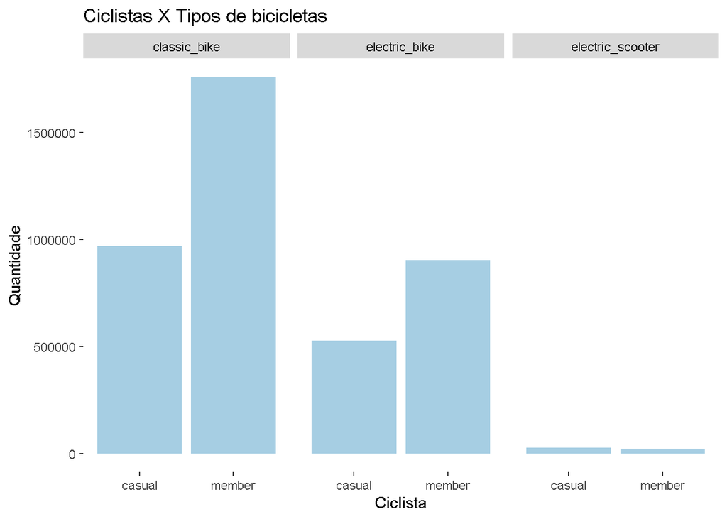

```r
trips_2024_clean %>%
  ggplot(aes(x = member_casual, fill = "blue")) +
  geom_bar(show.legend = F) +
  labs(title = "Ciclistas X Tipos de bicicletas", x = "Ciclista", y = "Quantidade") +
  theme(panel.background = element_blank()) +
  scale_fill_brewer(palette = 3, type = "qual") +
  facet_wrap(~rideable_type)
```

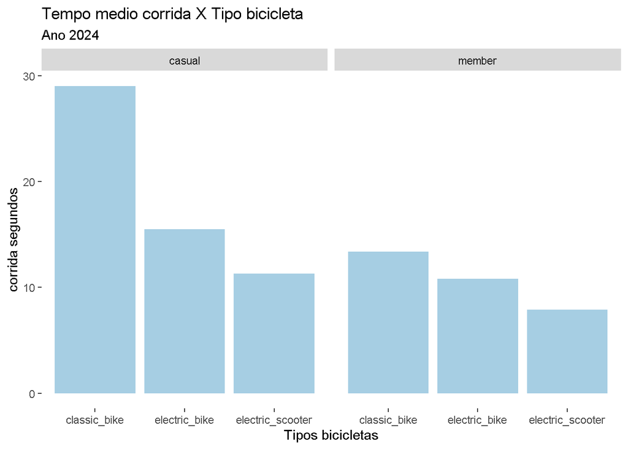

```r
trips_2024_clean %>%
  group_by(rideable_type, member_casual) %>%
  summarise(media = mean(lengt_ride_seconds)) %>%
ggplot(aes(x = rideable_type, y = media)) +
  geom_col(aes(fill = "blue"), show.legend = F) +
  labs(title = "Tempo medio corrida X Tipo bicicleta", subtitle = "Ano 2024", y = "corrida segundos", x = "Tipos bicicletas") +
  theme(panel.background = element_blank()) +
  scale_fill_brewer(palette = 3, type = "qual") +
  facet_wrap(~member_casual)
```

Analisando os tipos de bicicletas e ciclistas em relação ao total de viagens por mes

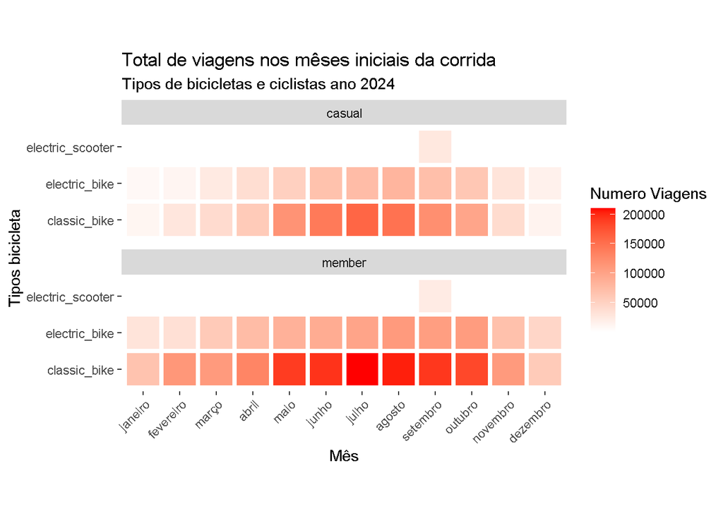

```r
trips_2024_clean %>%
  group_by(member_casual, rideable_type, month_start) %>%
  summarise(viagens = n()) %>%
  ggplot(aes(x = month_start, y = rideable_type, fill = viagens)) +
    geom_tile(color = "white", lwd = 1.5, linetype = 1) +
    scale_fill_gradient(low = "white", high = "red") +
    labs(title = "Total de viagens nos mêses iniciais da corrida", subtitle = "Tipos de bicicletas e ciclistas ano 2024", y = "Tipos bicicleta", x = "Mês", fill = "Numero Viagens") +
    theme(panel.background = element_blank(), axis.text.x = element_text(angle = 45, hjust = c(1,1))) +
    facet_wrap(~member_casual, nrow = 2) +
    coord_fixed()
```

Analisando os tipos de bicicletas e ciclistas em relação ao media de viagens por mes

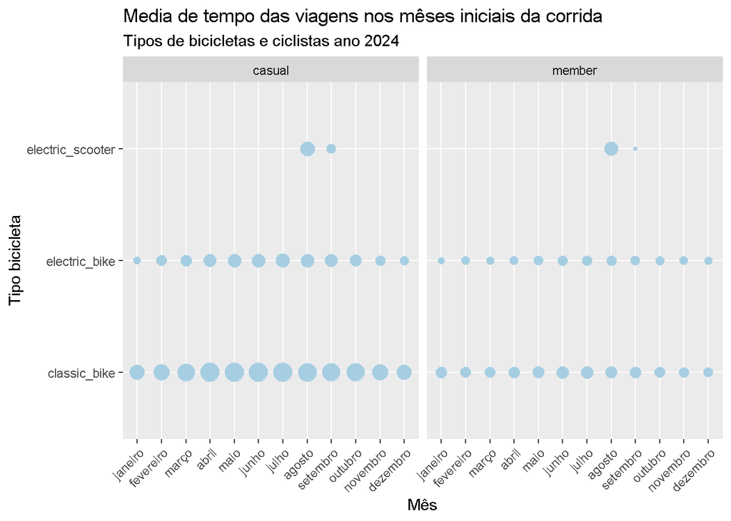

```r
trips_2024_clean %>%
  group_by(member_casual, rideable_type, month_start) %>%
  summarise(media = mean(lengt_ride_seconds)) %>%
  ggplot(aes(x = month_start, y = rideable_type, size = media)) +
    geom_count(mapping = aes(colour = "blue"), show.legend = F) +
    labs(title = "Media de tempo das viagens nos mêses iniciais da corrida", subtitle = "Tipos de bicicletas e ciclistas ano 2024", x = "Mês", y = "Tipo bicicleta", fill = "Ciclista") +
    theme(axis.text.x = element_text(angle = 45, hjust = c(1,1))) +
    scale_color_brewer(palette = 3, type = "qual") +
    facet_wrap(~member_casual)
```

Analisando os tipos de bicicletas e ciclistas em relação ao total de viagens por dia da semana

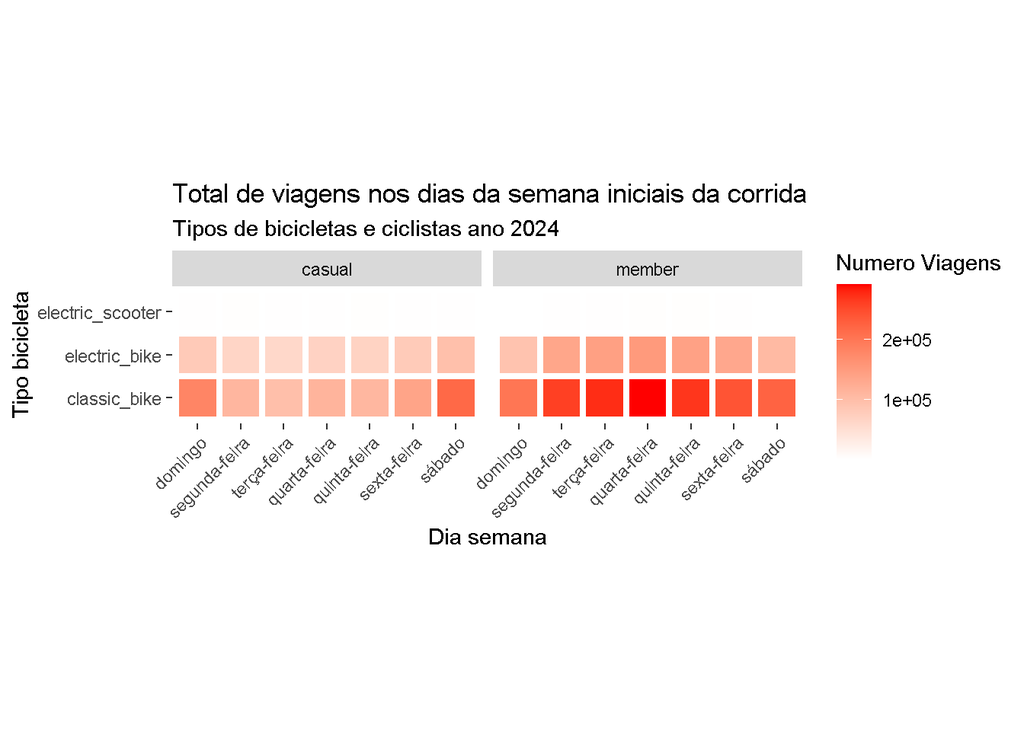

```r
trips_2024_clean %>%
  group_by(member_casual, rideable_type, day_of_week_start) %>%
  summarise(viagens = n()) %>%
  ggplot(aes(x = day_of_week_start, y = rideable_type, fill = viagens)) +
    geom_tile(color = "white", lwd = 1.5, linetype = 1) +
    scale_fill_gradient(low = "white", high = "red") +
    labs(title = "Total de viagens nos dias da semana iniciais da corrida", subtitle = "Tipos de bicicletas e ciclistas ano 2024", y = "Tipo bicicleta", x = "Dia semana", fill = "Numero Viagens") +
    theme(panel.background = element_blank(), axis.text.x = element_text(angle = 45, hjust = c(1,1))) +
    facet_wrap(~member_casual) +
    coord_fixed()
```

Analisando os tipos de bicicletas e ciclistas em relação ao media de viagens por dia de semana

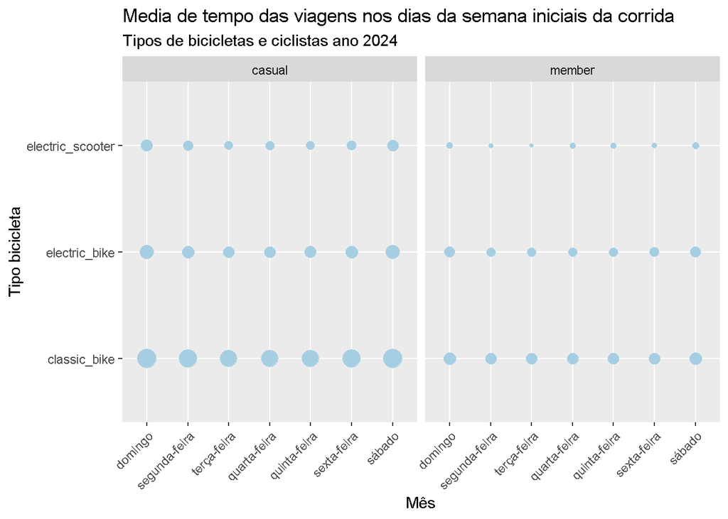

```r
trips_2024_clean %>%
  group_by(member_casual, rideable_type, day_of_week_start) %>%
  summarise(media = mean(lengt_ride_seconds)) %>%
  ggplot(aes(x = day_of_week_start, y = rideable_type, size = media)) +
    geom_count(mapping = aes(colour = "blue"), show.legend = F) +
    labs(title = "Media de tempo das viagens nos dias da semana iniciais da corrida", subtitle = "Tipos de bicicletas e ciclistas ano 2024", x = "Mês", y = "Tipo bicicleta", fill = "Ciclista") +
    theme(axis.text.x = element_text(angle = 45, hjust = c(1,1))) +
    scale_color_brewer(palette = 3, type = "qual") +
    facet_wrap(~member_casual)
```

```r
viagens_casual <- trips_2024_clean %>%
  filter(member_casual == "casual") %>%
  group_by(start_station_name, end_station_name) %>%
  summarise(media = mean(lengt_ride_seconds), viagens = n())
viagens_member <- trips_2024_clean %>%
  filter(member_casual == "member") %>%
  group_by(start_station_name, end_station_name) %>%
  summarise(media = mean(lengt_ride_seconds), viagens = n())
```

Fazendo um mapa de calor com total de viagens feitas por ciclistas casuais

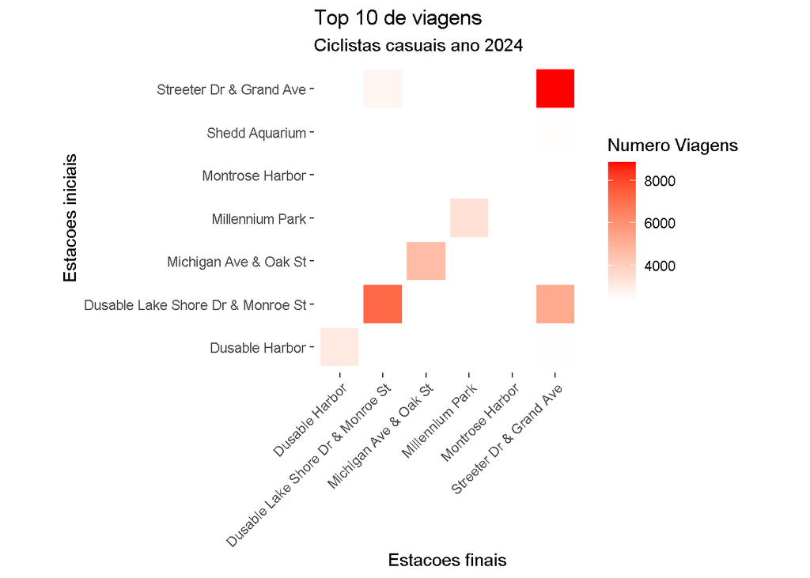

```r
viagens_casual %>%
  arrange(desc(viagens)) %>%
  head(10) %>%
  ggplot(aes(x = end_station_name, y = start_station_name, fill = viagens)) +
    geom_tile(color = "white", lwd = 1.5, linetype = 1) +
    scale_fill_gradient(low = "white", high = "red") +
    labs(title = "Top 10 de viagens", subtitle = "Ciclistas casuais ano 2024", x = "Estacoes finais", y = "Estacoes iniciais", fill = "Numero Viagens") +
    theme(panel.background = element_blank(), axis.text.x = element_text(angle = 45, hjust = c(1,1))) +
    coord_fixed()
```

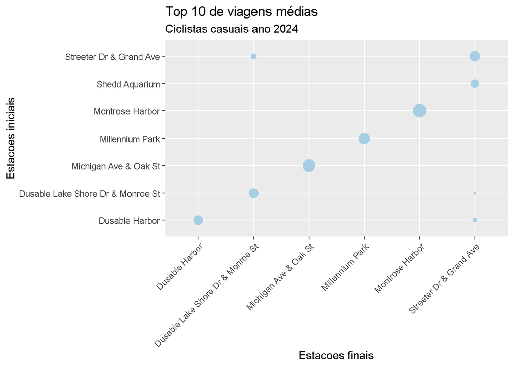

```r
viagens_casual %>%
  arrange(desc(viagens)) %>%
  head(10) %>%
  ggplot(aes(x = end_station_name, y = start_station_name, size = media)) +
    geom_count(mapping = aes(colour = "blue"), show.legend = F) +
    labs(title = "Top 10 de viagens médias", subtitle = "Ciclistas casuais ano 2024", x = "Estacoes finais", y = "Estacoes iniciais") +
    theme(axis.text.x = element_text(angle = 45, hjust = c(1,1))) +
    scale_color_brewer(palette = 3, type = "qual")
```

Fazendo um mapa de calor com total de viagens feitas por ciclistas assinantes

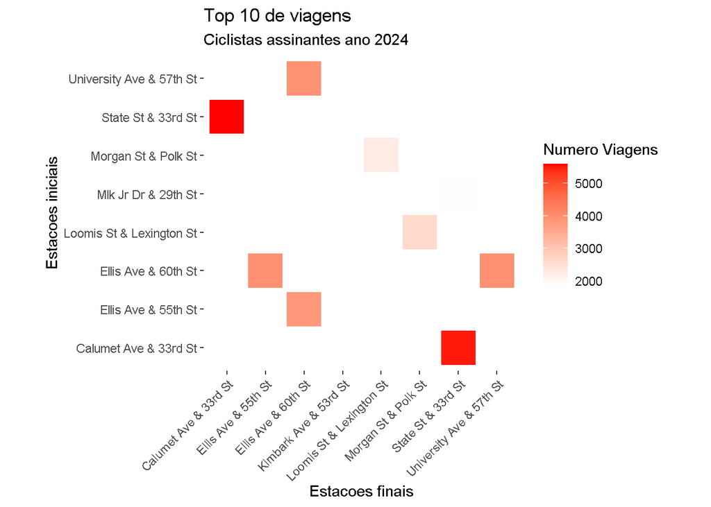

```r
viagens_member %>%
  arrange(desc(viagens)) %>%
  head(10) %>%
  ggplot(aes(x = end_station_name, y = start_station_name, fill = viagens)) +
    geom_tile(color = "white", lwd = 1.5, linetype = 1) +
    scale_fill_gradient(low = "white", high = "red") +
    labs(title = "Top 10 de viagens", subtitle = "Ciclistas assinantes ano 2024", x = "Estacoes finais", y = "Estacoes iniciais", fill = "Numero Viagens") +
    theme(panel.background = element_blank(), axis.text.x = element_text(angle = 45, hjust = c(1,1))) +
    coord_fixed()
```

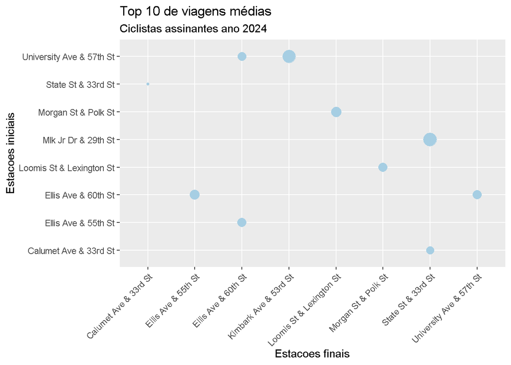

```r
viagens_member %>%
  arrange(desc(viagens)) %>%
  head(10) %>%
  ggplot(aes(x = end_station_name, y = start_station_name, size = media)) +
    geom_count(mapping = aes(colour = "blue"), show.legend = F) +
    labs(title = "Top 10 de viagens médias", subtitle = "Ciclistas assinantes ano 2024", x = "Estacoes finais", y = "Estacoes iniciais") +
    theme(axis.text.x = element_text(angle = 45, hjust = c(1,1))) +
    scale_color_brewer(palette = 3, type = "qual")
```